# Imputing the epigenome

March 12, 2015

[figure not shown]

(Ernst and Kellis 2015)

## Main Idea

Exploit the correlated nature of epigenetic signals, across both marks and samples, for large-scale prediction of additional datasets

## Matrix of Observed and Imputed Data

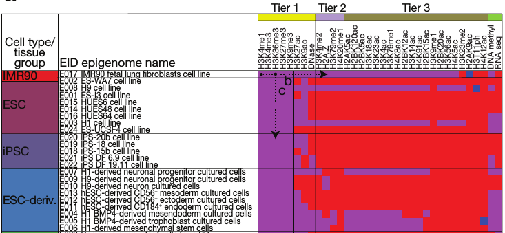

## 1. Leverage other marks in same sample

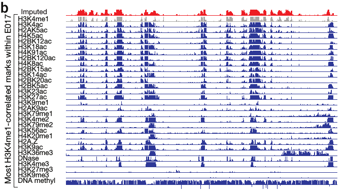

## 2. Leverage same mark in different sample

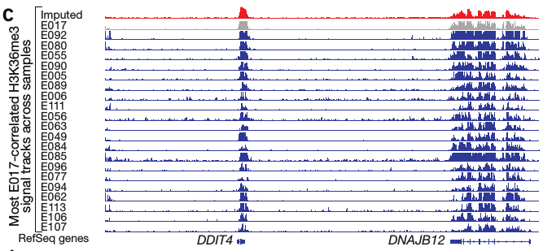

## Types of data used to impute

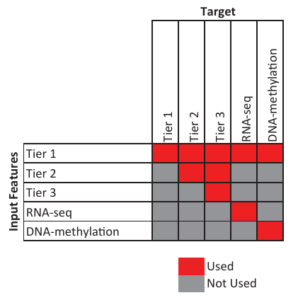

## Advantages of Imputation

- Beneficial even if observed data is available
  - Combining information –> robust to experimental noise, confounders
  - Achieve a higher sequencing depth –> higher signal to noise ratio
- Improve GWAS enrichments –> epigenomic maps as an unbiased approach for discovering disease-relevant tissues and cell types
- Quality Control –> Are there discrepancies between imputed and observed datasets
- Feature importance
- Chromatin state annotation

## Limitations

- If the presence of mark signal is highly specific to one or a few samples, and it does not correlate with other marks mapped in the sample or has a different correlation structure than in samples used for training, then it would not be possible to accurately impute the mark at those locations
- When the target mark has been mapped in only a few samples, the features pertaining to the same mark in other samples may be less informative or more biased e.g. TFBS
- For tissue samples that reflect mixtures of multiple cell types, our imputed maps will most likely reflect the same mixture as the observed data, though deconvolution of mixed samples is a potentially important direction for future work

## ChromImpute Software

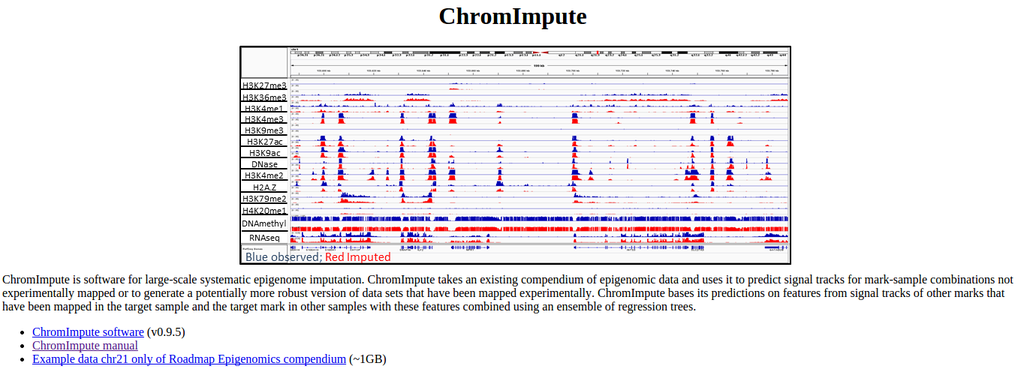

- Command line tool written in `JAVA`
- http://www.biolchem.ucla.edu/labs/ernst/ChromImpute/

## Not a new idea

## Leo Breiman (1928-2005)

[figure not shown]

[figure not shown]

(Breiman 2001)

[`randomForest` package in `R`](http://cran.r-project.org/package=randomForest)

## MissForest

[figure not shown]

(Stekhoven and B ühlmann 2012)

[`missForest` package in `R`](http://cran.r-project.org/package=missForest)

## Introduction to Regression Trees

## Some intuition behind the imputation approach

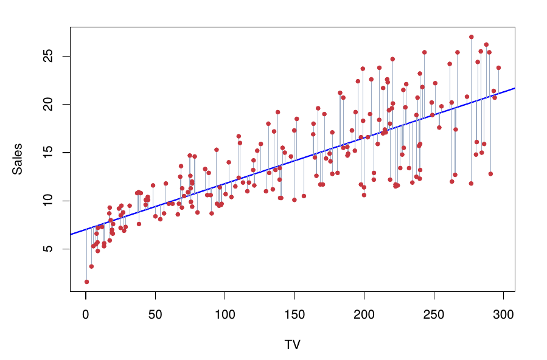

`total sales = 7.1 + 0.0475 x # of TV's sold`

## Tree-based Methods

- Involves *splitting* the predictor space into simple regions
- Since the set of splitting rules used to segment the predictor space can be summarized in a tree, these types of approaches are known as decision-tree methods (James et al. 2013)

## Baseball Data

|  | Years | Hits | Salary |
| --- | --- | --- | --- |
| -Andy Allanson | 1 | 66 |  |
| -Alan Ashby | 14 | 81 | 475 |
| -Alvin Davis | 3 | 130 | 480 |
| -Andre Dawson | 11 | 141 | 500 |
| -Andres Galarraga | 2 | 87 | 91.5 |
| -Alfredo Griffin | 11 | 169 | 750 |
| -Al Newman | 2 | 37 | 70 |
| -Argenis Salazar | 3 | 73 | 100 |
| -Andres Thomas | 2 | 81 | 75 |
| -Andre Thornton | 13 | 92 | 1100 |

[output cut: 312 more lines]

## Predict salary based on Hits and Years Played

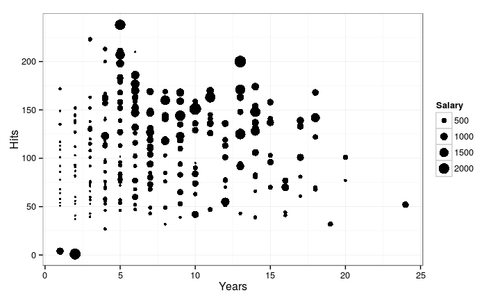

## How to split the data

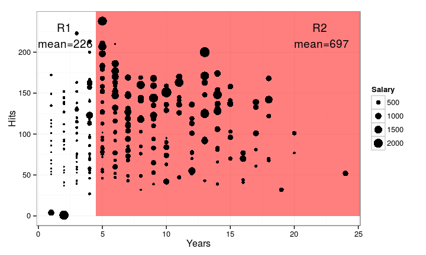

## How to split the data

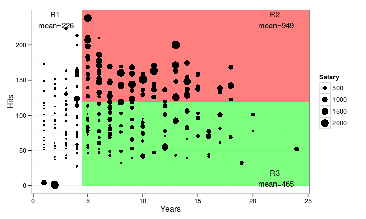

## How to split the data

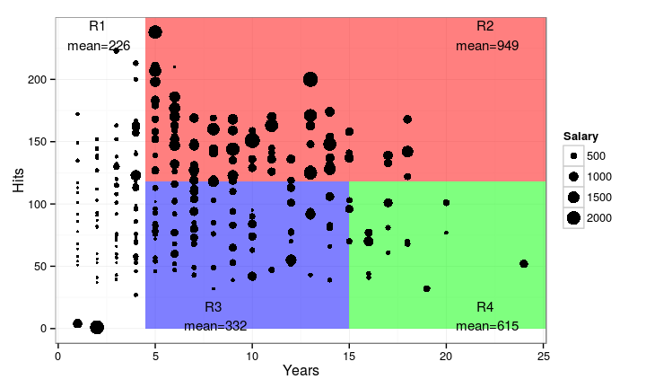

## How to split the data

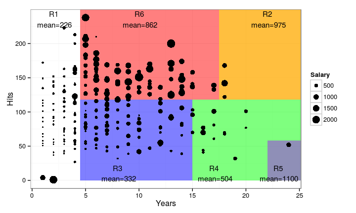

## Regression Tree for Baseball data

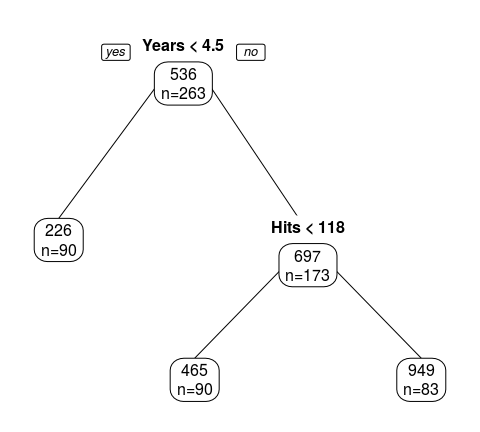

```
- Years is the most important factor in
determining Salary
- Given that a player is less
experienced, the number of Hits that
he made in the previous year seems
to play little role in his Salary
- Among players who have been in
the major leagues for five or more years,
the number of Hits made in the previous
year does affect Salary
```

## Decision Tree

[figure not shown]

## More Details of Tree Building

- The goal is to find boxes \(R_1,\ldots, R_J\) that minimize the residual sum of squares give by
- \[ \sum_{j=1}^J \sum_{i \in R_j} (y_i - \hat{y}_{Rj}) \]
- \(y_i\) is the subjects response, \(\hat{y}_{Rj}\) is the mean in box \(j\)
- Computationally infeasible to consider every single partition of the feature space into J boxes
- Solution: take a top-down, greedy approach
- Begins at the top, and never looks back

## Pros and Cons

- Tree-based methods are simple and useful for interpretation
- Highly sensity to the first split
- Solution: Combining a large number of trees can often result in dramatic improvements in prediction accuracy, at the expense of some loss interpretation.

## Bagging

## The Bootstrap

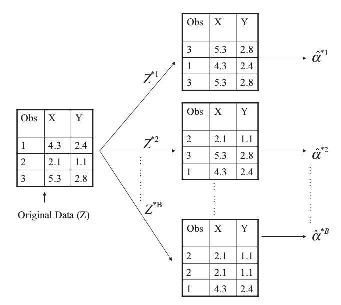

(James et al. 2013)

## Pull yourself up by your bootstraps

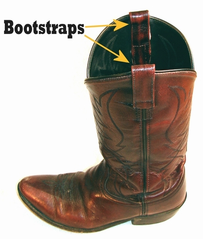

## Random Forests

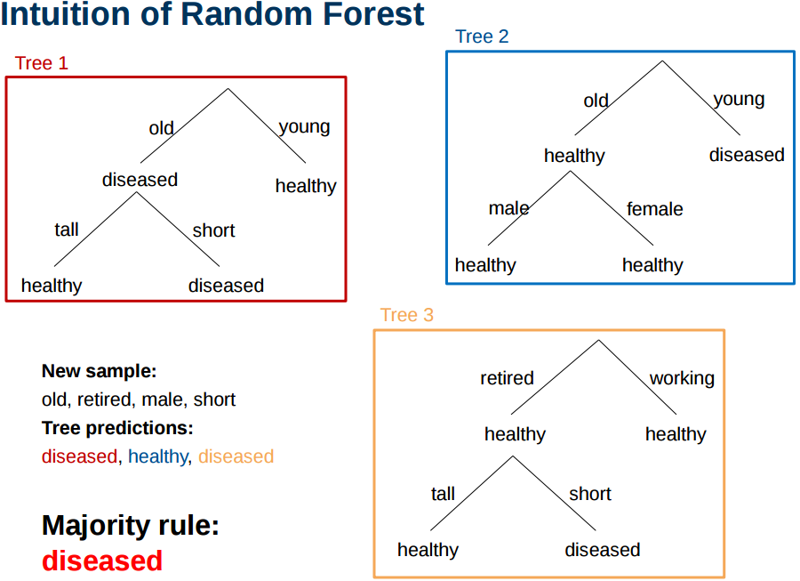

[ETH Zurich Slides](http://stat.ethz.ch/education/semesters/ss2012/ams/slides/v10.2.pdf)

## Acknowledgements

## Regression tree slides are based on

[figure not shown]

## Leo Breiman (1928-2005)

[figure not shown]

## References

Breiman, Leo. 2001. “Random Forests.” *Mach. Learn.* 45 (1). Hingham, MA, USA: Kluwer Academic Publishers: 5–32. doi:10.1023/A:1010933404324.

Ernst, Jason, and Manolis Kellis. 2015. “Large-Scale Imputation of Epigenomic Datasets for Systematic Annotation of Diverse Human Tissues.” *Nature Biotechnology*. Nature Publishing Group.

James, G, D Witten, T Hastie, and R Tibshirani. 2013. *An Introduction to Statistical Learning*.

Stekhoven, Daniel J, and Peter B ühlmann. 2012. “MissForest—non-Parametric Missing Value Imputation for Mixed-Type Data.” *Bioinformatics* 28 (1). Oxford Univ Press: 112–18.